# Sick dataset analysis

## 4.7 SAFE

For this purpose, we will use the SAFE method, which will allow us to transform data in a similar way as the previously mentioned models do.

### 4.7.1 Random Forest

```r
model_rf1 <- randomForest(Class ~., data = data_tr[1:2000,])
explainer_rf1 <- explain(model_rf1, data=select(data_tr[2001:3010,], -Class), y=as.numeric(as.character(data_tr[2001:3010,]$Class)), label = "rf1", verbose = FALSE)
safe_extractor <- safe_extraction(explainer_rf1, penalty = 10, verbose = FALSE)
print(safe_extractor)
```

```
## Variable 'age' - selected intervals:
##  (-Inf, 43]
##      (43, 70]
##      (70, Inf)
## Variable 'sex' - no transformation suggested.
## Variable 'on_thyroxine' - no transformation suggested.
## Variable 'query_on_thyroxine' - no transformation suggested.
## Variable 'on_antithyroid_medication' - no transformation suggested.
## Variable 'sick' - no transformation suggested.
## Variable 'pregnant' - no transformation suggested.
## Variable 'thyroid_surgery' - no transformation suggested.
## Variable 'I131_treatment' - no transformation suggested.
## Variable 'query_hypothyroid' - no transformation suggested.
## Variable 'query_hyperthyroid' - no transformation suggested.
## Variable 'lithium' - no transformation suggested.
## Variable 'goitre' - no transformation suggested.
## Variable 'tumor' - no transformation suggested.
## Variable 'psych' - no transformation suggested.
## Variable 'TSH_measured' - no transformation suggested.
## Variable 'TSH' - selected intervals:
##  (-Inf, -1.357479]
##      (-1.357479, -0.07257069]
##      (-0.07257069, 1.131402]
##      (1.131402, Inf)
## Variable 'T3_measured' - no transformation suggested.
## Variable 'T3' - selected intervals:
##  (-Inf, 1.1]
##      (1.1, 1.9]
##      (1.9, 2.7]
##      (2.7, Inf)
## Variable 'TT4_measured' - no transformation suggested.
## Variable 'TT4' - selected intervals:
##  (-Inf, 53]
##      (53, 76]
##      (76, 152.6327]
##      (152.6327, Inf)
## Variable 'T4U_measured' - no transformation suggested.
## Variable 'T4U' - selected intervals:
##  (-Inf, 0.84]
##      (0.84, 1.02]
##      (1.02, 1.18]
##      (1.18, Inf)
## Variable 'FTI_measured' - no transformation suggested.
## Variable 'FTI' - selected intervals:
##  (-Inf, 63]
##      (63, 88]
##      (88, 101]
##      (101, 126]
##      (126, Inf)
## Variable 'referral_source' - created levels:
##  SVHC, other, STMW ->  SVHC_other_STMW
##  SVI, SVHD ->  SVI_SVHD
```

We can see how does SAFE algorithm transform data base on Random Forest.

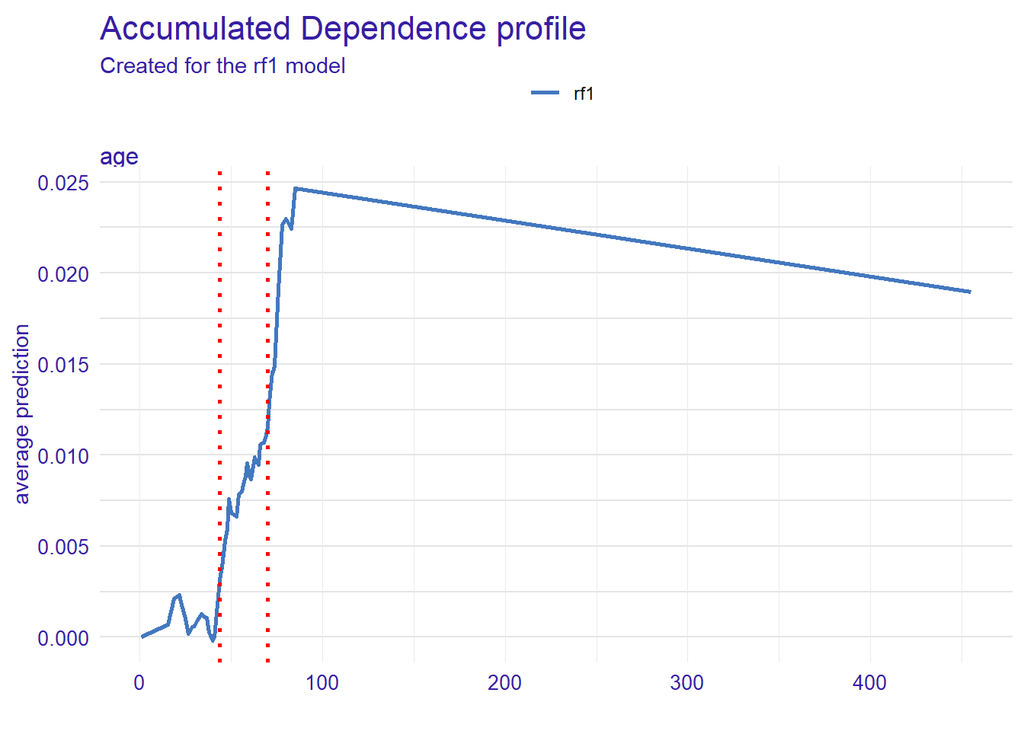

```r
plot(safe_extractor, variable = "age")
```

[figure not shown]

```r
plot(safe_extractor, variable = "TT4")
```

The charts show how new variables arose.

[figure not shown]

```r
plot(safe_extractor, variable = "referral_source")
```

#### 4.7.1.1 Transformation

Now we will process our data in accordance with SAFE extractor and choose the most valuable new and old ones.

```r
data1 <- safely_transform_data(safe_extractor, data_tr, verbose = FALSE)
vars <- safely_select_variables(safe_extractor, data1, which_y = "Class", verbose = FALSE)
data1 <- data1[,c("Class", vars)]

print(vars)
```

```
##  [1] "age"                       "sex"
##  [3] "on_thyroxine"              "query_on_thyroxine"
##  [5] "on_antithyroid_medication" "sick"
##  [7] "pregnant"                  "thyroid_surgery"
##  [9] "I131_treatment"            "query_hypothyroid"
## [11] "query_hyperthyroid"        "lithium"
## [13] "goitre"                    "tumor"
## [15] "psych"                     "TSH_measured"
## [17] "TSH"                       "T3_measured"
## [19] "TT4_measured"              "T4U_measured"
## [21] "FTI_measured"              "FTI"
## [23] "T3_new"                    "TT4_new"
## [25] "T4U_new"                   "referral_source_new"
```

```r
data1t <- safely_transform_data(safe_extractor, data_ts, verbose = FALSE)
data1t <- data1t[,c("Class", vars)]
```

These variables were choosen.

#### 4.7.1.2 Comparing with old data

```r
task <- mlr::makeClassifTask(id = "1", data = data1, target = "Class", positive = 1)


modctree2 <- mlr::train(ctree, task)
modlog2 <- mlr::train(logreg, task)
modknn2 <- mlr::train(neigh, task)
modnaive2 <- mlr::train(naive, task)


task1 <- mlr::makeClassifTask(id = "1", data = data_tr, target = "Class", positive = 1)
task2 <- mlr::makeClassifTask(id = "2", data = data1, target = "Class", positive = 1)
tasks <- list(task1,task2)
rd <- makeResampleDesc("CV", iters=5)
bmr <- benchmark(learners = logreg, tasks = tasks, resamplings = rd, measures = auc, show.info = F)
pred <- getBMRPredictions(bmr)

truth <- pred$`1`$classif.logreg$data$truth
probs <- pred$`1`$classif.logreg$data$prob.1
fg <- probs[truth == 1]
bg <- probs[truth == 0]

roc <- roc.curve(scores.class0 = fg, scores.class1 = bg, curve = T)
roc$auc
```

```
## [1] 0.9328768
```

```r
truth <- pred$`2`$classif.logreg$data$truth
probs <- pred$`2`$classif.logreg$data$prob.1
fg <- probs[truth == 1]
bg <- probs[truth == 0]

roc <- roc.curve(scores.class0 = fg, scores.class1 = bg, curve = T)
roc$auc
```

```
## [1] 0.9595141
```

#### 4.7.1.3 Results

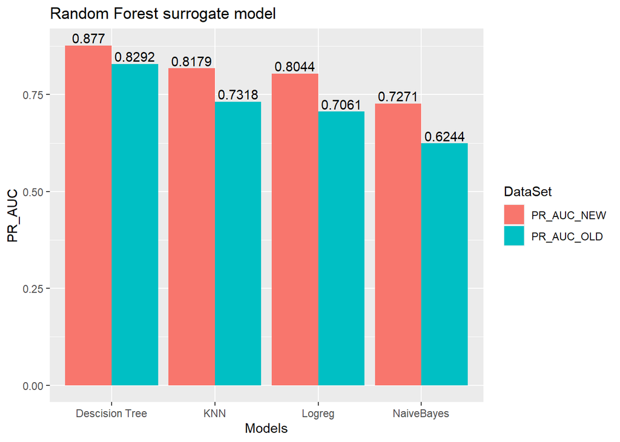

```r
dat <- data.frame(PR_AUC_OLD = c(pred_c2(data_tr, "rpart"),pred_c2(data_tr, "logreg"),pred_c2(data_tr, "kknn"),pred_c2(data_tr, "naiveBayes")), Models = c("Descision Tree", "Logreg", "KNN", "NaiveBayes"),PR_AUC_NEW = c(pred_c2(data1, "rpart"),pred_c2(data1, "logreg"),pred_c2(data1, "kknn"),pred_c2(data1, "naiveBayes")))

dat_long <- dat %>%
  gather("DataSet", "PR_AUC", -Models)

ggplot(dat_long, aes(x = Models, y = PR_AUC, fill = DataSet)) +
  geom_col(position = "dodge")+ geom_text(aes(label=sprintf("%0.4f", round(PR_AUC, digits = 4))), position=position_dodge(width=0.9), vjust=-0.25, parse = T) + ggtitle("Random Forest surrogate model")
```

We achieved quite good results thanks to this methods.

### 4.7.2 Xgboost

Now the same with the second algorithm.

```r
xg <- select(data_tr, -Class)

xg <- one_hot(data.table(xg))
xg$Class = select(data_tr, Class)
xg <- data.frame(xg)

xgt <- select(data_ts, -Class)

xgt <- one_hot(data.table(xgt))
xgt$Class = select(data_ts, Class)
xgt <- data.frame(xgt)

task <- mlr::makeClassifTask(id = "1", data = xg[1:2001,], target = "Class", positive = 1)

dt <- mlr::makeLearner(cl = "classif.xgboost", predict.type = "prob")
modxg <- mlr::train(dt, task)
pred <-  function(object, newdata) {pred <- predict(object, newdata=newdata)
                                              response <- pred$data[,3]
                                              return(as.numeric(as.character(response)))}

model_xg1 <- modxg
explainer_xg1 <- DALEX::explain(model_xg1, data=select(xg[2001:3010,], -Class), y=as.numeric(as.character(xg[2001:3010,]$Class)), label = "rf1", verbose = FALSE, predict_function = pred)
safe_extractorxg <- safe_extraction(explainer_xg1, penalty = 10, verbose = FALSE)

data1xg <- safely_transform_data(safe_extractorxg, xg, verbose = FALSE)
varsxg <- safely_select_variables(safe_extractorxg, data1xg, which_y = "Class", verbose = FALSE)
data1xg <- data1xg[,c("Class", varsxg)]


data1txg <- safely_transform_data(safe_extractorxg, xgt, verbose = FALSE)
data1txg <- data1txg[,c("Class", varsxg)]

task <- mlr::makeClassifTask(id = "1", data = data1xg, target = "Class", positive = 1)


modctree2xg <- mlr::train(ctree, task)
modlog2xg <- mlr::train(logreg, task)
modknn2xg <- mlr::train(neigh, task)
modnaive2xg <- mlr::train(naive, task)

task1 <- mlr::makeClassifTask(id = "1", data = data_tr, target = "Class", positive = 1)
task2 <- mlr::makeClassifTask(id = "2", data = data1xg, target = "Class", positive = 1)
tasks <- list(task1,task2)
rd <- makeResampleDesc("CV", iters=5)
bmr <- benchmark(learners = ctree, tasks = tasks, resamplings = rd, measures = auc, show.info = F)
pred <- getBMRPredictions(bmr)

truth <- pred$`1`$classif.rpart$data$truth
probs <- pred$`1`$classif.rpart$data$prob.1
fg <- probs[truth == 1]
bg <- probs[truth == 0]

roc <- roc.curve(scores.class0 = fg, scores.class1 = bg, curve = T)
roc$auc
```

```
## [1] 0.9278084
```

```r
truth <- pred$`2`$classif.rpart$data$truth
probs <- pred$`2`$classif.rpart$data$prob.1
fg <- probs[truth == 1]
bg <- probs[truth == 0]

roc <- roc.curve(scores.class0 = fg, scores.class1 = bg, curve = T)
roc$auc
```

```
## [1] 0.9454704
```

#### 4.7.2.1 Results

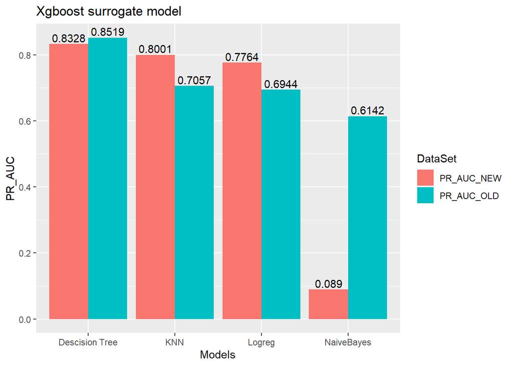

```r
dat <- data.frame(PR_AUC_OLD = c(pred_c2(data_tr, "rpart"),pred_c2(data_tr, "logreg"),pred_c2(data_tr, "kknn"),pred_c2(data_tr, "naiveBayes")), Models = c("Descision Tree", "Logreg", "KNN", "NaiveBayes"),PR_AUC_NEW = c(pred_c2(data1xg, "rpart"),pred_c2(data1xg, "logreg"),pred_c2(data1xg, "kknn"),pred_c2(data1xg, "naiveBayes")))

dat_long <- dat %>%
  gather("DataSet", "PR_AUC", -Models)

ggplot(dat_long, aes(x = Models, y = PR_AUC, fill = DataSet)) +
  geom_col(position = "dodge")+ geom_text(aes(label=sprintf("%0.4f", round(PR_AUC, digits = 4))), position=position_dodge(width=0.9), vjust=-0.25, parse = T) + ggtitle("Xgboost surrogate model")
```

# 5 Feature Selection

Now, based on the Random Forest model, we will begin to select variables.

```r
fit <- randomForest(Class~., data=data1)
VI_F <- randomForest::importance(fit)
VI_F <- data.frame(VI_F)
VI_F$names <- rownames(VI_F)
rownames(VI_F) <- NULL
VI_F <- data.table(VI_F[order(VI_F$MeanDecreaseGini,decreasing = T),])
VI_F
```

| MeanDecreaseGini | names |
| --- | --- |
| 180.73320003 | T3_new |
| 29.36501259 | FTI |
| 22.12705265 | TSH |
| 19.39222003 | referral_source_new |
| 18.45916963 | TT4_new |
| 18.33807025 | age |
| 11.85973985 | T4U_new |
| 2.64017611 | sex |
| 2.39635596 | on_thyroxine |
| 2.26956605 | query_hypothyroid |

[output cut: 16 more lines]

We will how this selection affected PR AUC.

## 5.1 Logistic Regression

```r
task1 <- mlr::makeClassifTask(id = "1", data = data1, target = "Class", positive = 1)
task2 <- mlr::makeClassifTask(id = "2", data = dataFT, target = "Class", positive = 1)
tasks <- list(task1,task2)
rd <- makeResampleDesc("CV", iters=5)
bmr <- benchmark(learners = logreg, tasks = tasks, resamplings = rd, measures = auc, show.info = F)
pred <- getBMRPredictions(bmr)

truth <- pred$`1`$classif.logreg$data$truth
probs <- pred$`1`$classif.logreg$data$prob.1
fg <- probs[truth == 1]
bg <- probs[truth == 0]

pr <- pr.curve(scores.class0 = fg, scores.class1 = bg, curve = T)
pr$auc.integral
```

```
## [1] 0.8152706
```

```r
truth <- pred$`2`$classif.logreg$data$truth
probs <- pred$`2`$classif.logreg$data$prob.1
fg <- probs[truth == 1]
bg <- probs[truth == 0]

pr <- pr.curve(scores.class0 = fg, scores.class1 = bg, curve = T)
pr$auc.integral
```

```
## [1] 0.8333323
```

## 5.2 KNN

```r
dataFT <- data1[,VI_F[1:5,]$names]
dataFT$Class <- data1$Class

task1 <- mlr::makeClassifTask(id = "1", data = data1, target = "Class", positive = 1)
task2 <- mlr::makeClassifTask(id = "2", data = dataFT, target = "Class", positive = 1)
tasks <- list(task1,task2)
rd <- makeResampleDesc("CV", iters=5)
bmr <- benchmark(learners = neigh, tasks = tasks, resamplings = rd, measures = auc, show.info = F)
pred <- getBMRPredictions(bmr)

truth <- pred$`1`$classif.kknn$data$truth
probs <- pred$`1`$classif.kknn$data$prob.1
fg <- probs[truth == 1]
bg <- probs[truth == 0]

pr <- pr.curve(scores.class0 = fg, scores.class1 = bg, curve = T)
pr$auc.integral
```

```
## [1] 0.8321916
```

```r
truth <- pred$`2`$classif.kknn$data$truth
probs <- pred$`2`$classif.kknn$data$prob.1
fg <- probs[truth == 1]
bg <- probs[truth == 0]

pr <- pr.curve(scores.class0 = fg, scores.class1 = bg, curve = T)
pr$auc.integral
```

```
## [1] 0.9409652
```

WOW

## 5.3 Decision Tree

```r
dataFT <- data1[,VI_F[1:13,]$names]
dataFT$Class <- data1$Class

task1 <- mlr::makeClassifTask(id = "1", data = data1, target = "Class", positive = 1)
task2 <- mlr::makeClassifTask(id = "2", data = dataFT, target = "Class", positive = 1)
tasks <- list(task1,task2)
rd <- makeResampleDesc("CV", iters=5)
bmr <- benchmark(learners = ctree, tasks = tasks, resamplings = rd, measures = auc, show.info = F)
pred <- getBMRPredictions(bmr)

truth <- pred$`1`$classif.rpart$data$truth
probs <- pred$`1`$classif.rpart$data$prob.1
fg <- probs[truth == 1]
bg <- probs[truth == 0]

pr <- pr.curve(scores.class0 = fg, scores.class1 = bg, curve = T)
pr$auc.integral
```

```
## [1] 0.8468729
```

```r
truth <- pred$`2`$classif.rpart$data$truth
probs <- pred$`2`$classif.rpart$data$prob.1
fg <- probs[truth == 1]
bg <- probs[truth == 0]

pr <- pr.curve(scores.class0 = fg, scores.class1 = bg, curve = T)
pr$auc.integral
```

```
## [1] 0.8815179
```

We can see that thanks to this stage we have achieved a significant improvement in terms of PR AUC. In the case of KNN huge and unexpected given the previous results.

# 6 Tuning

Finally, we will start tuning selected models and carry out the final tests. The result will be AUC and PR AUC.  
In the report I did not include the results of adding data using the SMOKE function from the less occurring class and data scaling, because they did not positively affect the performance of the models.

## 6.1 Decison tree

```r
pred_c <- function(model, newdata)  {


  pred <- predict(model, newdata = newdata)
  prob <- getPredictionProbabilities(pred)


  fg <- prob[newdata[,"Class"] == 1]
  bg <- prob[newdata[,"Class"] == 0]

  roc <- roc.curve(scores.class0 = fg, scores.class1 = bg, curve = T)


  pr <- pr.curve(scores.class0 = fg, scores.class1 = bg, curve = T)
  a <- c(roc$auc, pr$auc.integral)
  return(a)
}

trainTask <- mlr::makeClassifTask(id = "1", data = data1, target = "Class", positive = 1)
makeatree <- makeLearner("classif.rpart", predict.type = "prob")
set_cv <- makeResampleDesc("CV",iters = 5L)
gs <- makeParamSet(
makeIntegerParam("minsplit",lower = 10, upper = 50),
makeIntegerParam("minbucket", lower = 5, upper = 50),
makeNumericParam("cp", lower = 0.001, upper = 0.2)
)



gscontrol <- makeTuneControlMBO()


stune <- tuneParams(learner = makeatree, resampling = set_cv, task = trainTask, par.set = gs, control = gscontrol, measures = auc)

t.tree <- setHyperPars(makeatree, par.vals = stune$x)

t.rpart <- mlr::train(t.tree, trainTask)
```

## 6.2 Decision tree final result

```r
t.tree <- setHyperPars(makeatree, par.vals = list(minsplit = 11, minbucket = 11, cp = 0.001019251))

t.rpart <- mlr::train(t.tree, trainTask)

pred_c(t.rpart, data1t)
```

```
## [1] 0.9920475 0.8524462
```

## 6.3 KNN

```r
dataFT <- data1[,VI_F[1:5,]$names]
dataFT$Class <- data1$Class

trainTask <- mlr::makeClassifTask(id = "1", data = dataFT, target = "Class", positive = 1)
makeatree <- makeLearner("classif.kknn", predict.type = "prob")
set_cv <- makeResampleDesc("CV",iters = 5L)
gs <- makeParamSet(
makeIntegerParam("k",lower = 5, upper = 15),
makeNumericParam("distance", lower = 1, upper = 2)
)



gscontrol <- makeTuneControlMBO()


stune <- tuneParams(learner = makeatree, resampling = set_cv, task = trainTask, par.set = gs, control = gscontrol, measures = auc)

t.kknn <- setHyperPars(makeatree, par.vals = stune$x)

t.kknn <- mlr::train(t.kknn, trainTask)
```

## 6.4 KNN final result

```r
pred_c(t.kknn, data1t)
```

```
## [1] 0.9945233 0.9227087
```

## 6.5 Logistic regression final result

```r
dataFT <- data1[,VI_F[1:13,]$names]
dataFT$Class <- data1$Class

task <- mlr::makeClassifTask(id = "1", data = dataFT, target = "Class", positive = 1)


modlog2 <- mlr::train(logreg, task)

pred_c(modlog2, data1t)
```

```
## [1] 0.9708009 0.8554779
```